# Milestone Report

cwl

6/5/2021

1. Introduction
   1. Background
   2. Objective
2. Dataset
   1. Source
   2. Data information
3. Data pre-processing
   1. Data sampling
   2. Data cleaning
   3. N-gram
4. Exploratory analysis
   1. Word frequencies
   2. Word Clouds
   3. Clustering
5. Findings
6. Future plans
7. Appendix A. Top 100 frequent words in N-gram
8. Appendix B. Full Code in R

## Introduction

### 1a. Background

This milestone report was a part of the course ([Data Science Capstone](https://www.coursera.org/learn/data-science-project?specialization=jhu-data-science)) offered by Johns Hopkins University on the Coursera platform. This course was under a specialization program, which consisted of 9 courses and a Capstone Project.

- Task 1: **Understanding the Problem**
- Task 2: **Data acquisition and cleaning**
- Task 3: **Exploratory analysis**
- Task 4: **Statistical modeling**
- Task 5: Predictive modeling
- Task 6: Creative exploration
- Task 7: Creating a data product
- Task 8: Creating a short slide deck pitching your product

### 1b. Objective

The objective of this report was to display the data we were working with, and to understand any basic relationships we were able observe in the data. In this report, we applied several natural language processing and text mining techniques in analyzing any new data.

## 2. Data

### 2a. Source

The course ([Data Science Capstone](https://www.coursera.org/learn/data-science-project?specialization=jhu-data-science) provided the training data, and it served as the basis for most of the capstone. The data was in English, German, Russian and Finnish, but we only considered the English one.

**[Capstone Dataset](https://d396qusza40orc.cloudfront.net/dsscapstone/dataset/Coursera-SwiftKey.zip)**

1. en_US.blogs.txt
2. en_US.news.txt
3. en_US.twitter.txt

### 2b. Data basic information

We summarized the basic summary of the dataset, trying to understand their contents. You may preview a few lines of each dataset.

[output not shown]

#### Examples of Twitter data:

```
## [1] "u not getting rid of that beard are ya?"
## [2] "Hope you are well lady. Keep me posted on all the goings on. :D I will text you when I find my phone"
## [3] "you guys doing Danny James' \"Pear\" on lp?!"
```

#### Examples of blog data:

```
## [1] "He looked back at me, his eyes were as dark as coal,"
## [2] "You've set up a problem without stakes. Why does she care who the voice on the phone is? Why would she even listen to him past \"hello?\""
## [3] "Yvonne Strahovski … Peg Mooring"
```

#### Examples of news data:

```
## [1] "It’s a nice thought, but don’t expect state Democrats Stephen Sweeney or Sheila Oliver to be raising their glasses to Christie anytime soon, even if he does throw his name in the presidential race. The terms \"rotten bastard\" and \"mentally deranged,\" words that those two critics recently …
## [2] "In an \"A\" review, Drew McWeeny of HitFix.com writes Lawrence invests Katniss \"with a rich inner life that makes her feel real. It is a pure movie star performance, and Lawrence rises to the occasion.\""
## [3] "This is also according to advice I've given others: We're flawed, all of us, and hoping to find an ideal person is not only pointless, it's also dehumanizing to people to expect them to meet your ideals. All you can realistically hope for are people who are self-aware enough and responsible …
```

## 3. Data pre-processing

### 3a. Data sampling

This dataset was fairly large. Our objective was to visualize and understand the outline of dataset, so it was unnecessary to load the entire dataset in to build our algorithms. We sampled a small part of it to do so.

The new summary for samples was:

```
##               Lines_counts Word_counts File_size
## en_US.twitter        23601     1620306    3.2 Mb
## en_US.blogs           8992     2044519    2.5 Mb
## en_US.news           10102     2044519    2.6 Mb
```

### 3b. Data cleaning

As we can obeserve from the samples, there were some unnecessary information such as stopswords, punctuation. In the next step, we performed the following data cleaning to remove these unnecessary information

- Convert to lowercase
- Remove URLs
- Remove punctuation
- remove numbers
- Removing English stopwords (common words)
- Remove special characters
- Stemming (reducing a word to its word stem that affixes to suffixes and prefixes or to the roots of words )

```
## [1] "Corpus size after cleaning: 173.9 Mb"
```

#### Examples of our corpus after processing:

```
## [[1]] u get rid beard ya
## [[2]] hope well ladi keep post go d text find phone
## [[3]] guy danni jame pear lp
## [[4]] excit wonder christma
## [[5]] money want usa visa areno question ask got prove
```

### 3c. N-gram

After data cleaning, we performed a N-gram preprocessing step to identify appropriate words.

N-gram refered to segmenting an input stream into all combinations of adjacent words of length n in our corpus.

- Unigram: a single letter, syllable, or word.
- Bigram: a pair of consecutive written units such as letters, syllables, or words.
- Trigram: a group of three consecutive written units such as letters, syllables, or words.

Then, we created a term document matrix to get the frequency of our words.

```r
# 2. N-gram
# create N-gram tern document matrix from a corpus
createNgram <- function(myCorpus, ngram = 1, lowfreq = NA) {
    toToken <- function(x) {
        # x contains x[1]$content and x[2]$meta
        unlist(tokenize_ngrams(content(x), n = ngram, n_min = ngram))
    }

    # TDM automatically discards words less than three characters.
    tdm <- TermDocumentMatrix(myCorpus, control = list(tokenize = toToken,
                                                       wordLengths=c(1, Inf)))

    if (!is.na(lowfreq)) {
        # remove infrequent words to reduce size
        freqTerms <- findFreqTerms(tdm, lowfreq = lowfreq)
        tdm <- tdm[freqTerms, ]
    }
    tdm
}

convertTdmToDf <- function(tdm) {
    # Reduce documents dimension and convert to dataframe
    # df <- data.frame(rowSums(as.matrix(tdm))) # exhaust memory
    df <- slam::row_sums(tdm, na.rm = T)
    df <- data.frame(word = names(df), freq = as.integer(df))  %>%
        arrange(desc(freq))
    rm(tdm)
    print(paste0("Ngram size: ", format(object.size(df), units = "Mb")))
    df
}

# N-gram
# removeSparseTerms: remove sparse words to contain around 1000 frequent words

# Unigram
tdm1 <- createNgram(myCorpus, n = 1, lowfreq = 1)
freq1 <- convertTdmToDf(tdm1) # Create a frequency sorted dataframe for tokens
```

```
## [1] "Ngram size: 2.8 Mb"
```

```r
# Bigram
tdm2 <- createNgram(myCorpus, n = 2, lowfreq = 1)
freq2 <- convertTdmToDf(tdm2) # Create a frequency sorted dataframe for tokens
```

```
## [1] "Ngram size: 29.7 Mb"
```

```r
# Trigram
tdm3 <- createNgram(myCorpus, n = 3, lowfreq = 1)
freq3 <- convertTdmToDf(tdm3) # Create a frequency sorted dataframe for tokens
```

```
## [1] "Ngram size: 38.8 Mb"
```

```r
rm(myCorpus)
```

#### Examples of Unigram after processing:

```
##  [1] "woodyarddr"   "worsehi"      "hooti"        "pkfz"         "sayit"
##  [6] "sprung"       "hoegaarden"   "basiloregano" "reput"        "obes"
```

#### Examples of Bigram after processing:

```
##  [1] "mason team"    "comescu salin" "rememb beauti" "quit enamour"
##  [5] "depp ask"      "vengeanc moon" "still kurt"    "start lose"
##  [9] "stress manag"  "movi tub"
```

#### Examples of Triigram after processing:

```
##  [1] "look hott alway"       "disloc shoulder head"  "physic talent great"
##  [4] "thick larg tasti"      "part middl class"      "ever sure your"
##  [7] "squar feet ultim"      "royalti author due"    "robert garrigus found"
## [10] "s glamour design"
```

## 4. Exploratory analysis

We built figures and tables to understand variation in the frequencies of words and word pairs in our data.

### 4a. Word frequencies

This part shows the top 20 frequent terms of our N-gram pre-processing.

In appendix A, you may find the top 100 frequent words in N-gram.

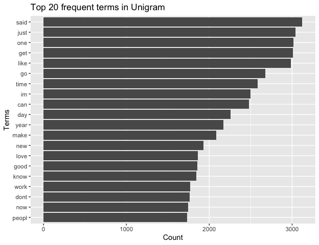

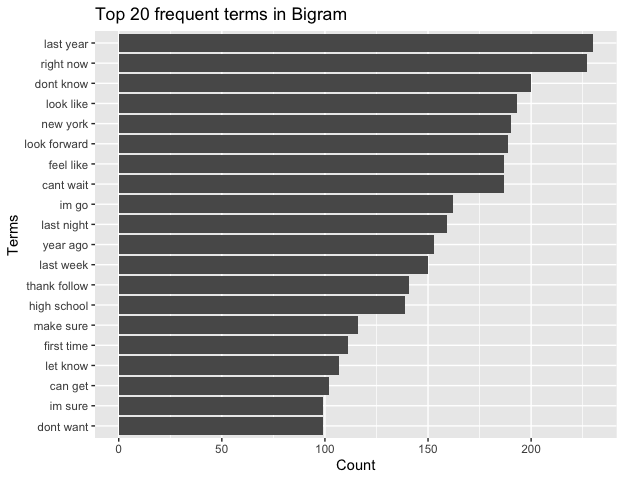

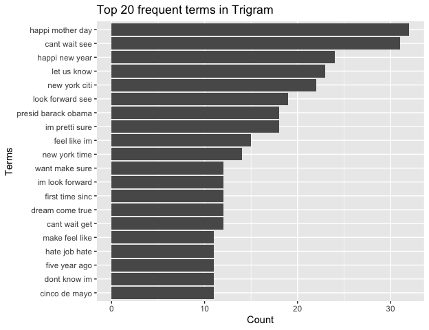

### 4b. Word clouds

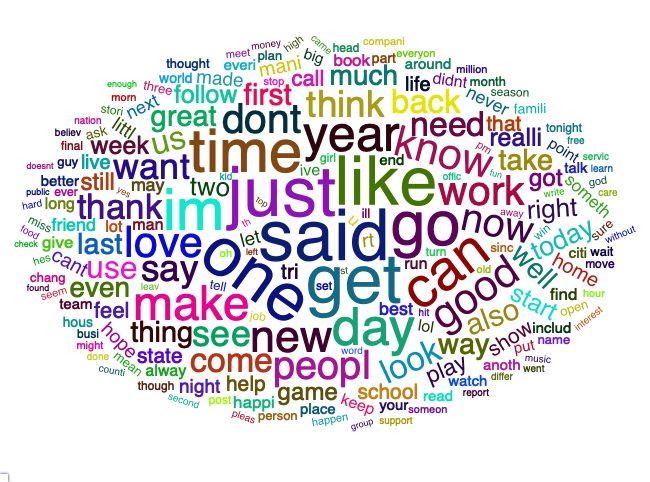

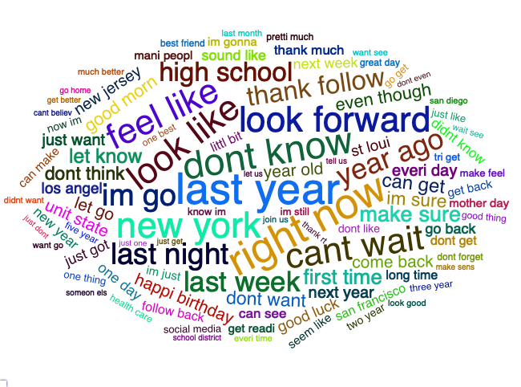

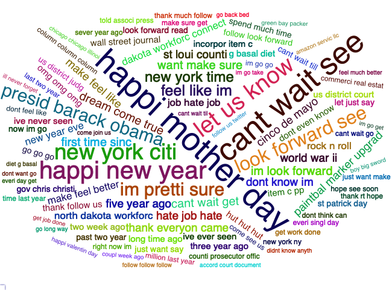

### 4c. Clustering

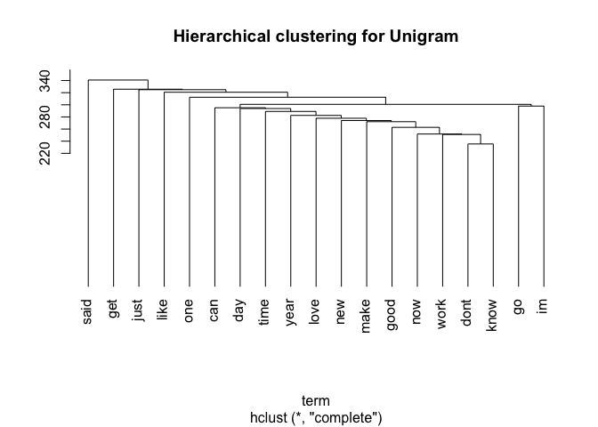

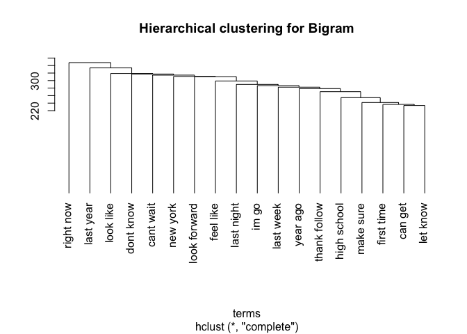

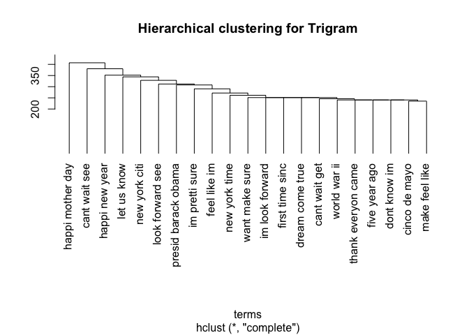

## 5. Findings

Interestingly, we found that Bigram and Trigram contain more information than Unigram. There were some common topics or phrases. N-gram could provide a glance at trending topics.

We also found that Twitter data included a lot of shorthand and improper English words. We had to reconsider if Twitter data was a trustworthy source for our ultimate goal: word prediction.

When reviewing our data, although we focused only on English, some special characters and non-English words might still exist. So, we decided to remove all non-English characters, and to perform stemming in our pre-precessing data.

Finally, processing data was quite time-consuming, especially when converted to a term-document matrix. Due to computational limitations, we were only able to process a sample of the original data that was needed. Therefore, we might have to look for a better dataset to save our resources in our next step.

## 6. Future plans

As explained in our background information, our ultimate goal is to develop a text prediction application based on our prediction algorithm. We will deploy this application on a Shiny server to make our Shiny application available over the web.

To achieve this objective, we have to train an accurate prediction algorithm. The data analysis in the report provided us with an insight that words frequency and the combination might be a possible way for text prediction. However, this method required us to process an enormous amount of data.

Therefore, we may also consider Hidden Markov Models (HMM) for text prediction. A hidden Markov model is a statistical model that models sequential data. It is usual for speech recognition, part-of-speech tagging, gene prediction etc. However, this model requires a good dataset for training.

For our application, we want to provide an interactive text prediction feature. Providing a list of texts as a prediction result would be a possible way. Users can inspect the probability of each text prediction, and pick the one they like.

## Appendix A. Top 100 frequent words in N-gram

```
##   [1] "said"   "just"   "one"    "get"    "like"   "go"     "time"   "im"
##   [9] "can"    "day"    "year"   "make"   "new"    "love"   "good"   "know"
##  [17] "work"   "dont"   "now"    "peopl"  "say"    "think"  "see"    "want"
##  [25] "thank"  "look"   "come"   "need"   "us"     "back"   "use"    "also"
##  [33] "first"  "well"   "great"  "thing"  "way"    "last"   "take"   "even"
##  [41] "much"   "today"  "two"    "right"  "start"  "follow" "realli" "week"
##  [49] "got"    "still"  "game"   "play"   "feel"   "call"   "show"   "help"
##  [57] "state"  "school" "tri"    "that"   "rt"     "life"   "mani"   "cant"
##  [65] "live"   "home"   "let"    "hope"   "littl"  "made"   "night"  "best"
##  [73] "may"    "never"  "friend" "next"   "book"   "u"      "happi"  "someth"
##  [81] "give"   "find"   "didnt"  "lol"    "lot"    "keep"   "alway"  "man"
##  [89] "ive"    "run"    "long"   "citi"   "watch"  "place"  "better" "anoth"
##  [97] "put"    "your"   "everi"  "end"
```

```
##   [1] "last year"       "right now"       "dont know"       "look like"
##   [5] "new york"        "look forward"    "cant wait"       "feel like"
##   [9] "im go"           "last night"      "year ago"        "last week"
##  [13] "thank follow"    "high school"     "make sure"       "first time"
##  [17] "let know"        "can get"         "dont want"       "im sure"
##  [21] "dont think"      "even though"     "good morn"       "let go"
##  [25] "come back"       "happi birthday"  "year old"        "unit state"
##  [29] "everi day"       "next year"       "just want"       "new jersey"
##  [33] "los angel"       "st loui"         "good luck"       "next week"
##  [37] "just got"        "sound like"      "one day"         "go back"
##  [41] "didnt know"      "new year"        "thank much"      "can see"
##  [45] "littl bit"       "long time"       "follow back"     "san francisco"
##  [49] "dont get"        "get back"        "mother day"      "get readi"
##  [53] "im just"         "mani peopl"      "can make"        "im gonna"
##  [57] "seem like"       "dont like"       "two year"        "now im"
##  [61] "one thing"       "go get"          "im still"        "just like"
##  [65] "know im"         "make feel"       "tri get"         "social media"
##  [69] "dont forget"     "health care"     "one best"        "five year"
##  [73] "pretti much"     "three year"      "best friend"     "good thing"
##  [77] "great day"       "join us"         "san diego"       "wait see"
##  [81] "want go"         "last month"      "much better"     "thank rt"
##  [85] "want see"        "didnt want"      "everi time"      "look good"
##  [89] "go home"         "just get"        "let us"          "make sens"
##  [93] "school district" "someon els"      "tell us"         "cant believ"
##  [97] "get better"      "just dont"       "just one"        "dont even"
```

```
##   [1] "happi mother day"        "cant wait see"
##   [3] "happi new year"          "let us know"
##   [5] "new york citi"           "look forward see"
##   [7] "im pretti sure"          "presid barack obama"
##   [9] "feel like im"            "new york time"
##  [11] "cant wait get"           "dream come true"
##  [13] "first time sinc"         "im look forward"
##  [15] "want make sure"          "cinco de mayo"
##  [17] "dont know im"            "five year ago"
##  [19] "hate job hate"           "make feel like"
##  [21] "paintbal marker upgrad"  "st loui counti"
##  [23] "thank everyon came"      "world war ii"
##  [25] "dakota workforc connect" "job hate job"
##  [27] "make feel better"        "new year eve"
##  [29] "north dakota workforc"   "rock n roll"
```

[output cut: 35 more lines]

## Appendix B. Full Code in R

```r
# Load libraries
require(tm); require(SnowballC); require(stopwords);
require(ggplot2); require(tokenizers);  require(dplyr);
require(wordcloud2); require(webshot); require(htmlwidgets)

url_tw <- "./data/en_US.twitter.txt"
url_blog <- "./data/en_US.blogs.txt"
url_news <- "./data/en_US.news.txt"
conn_tw <- file(url_tw,open="r")
conn_blog <- file(url_blog,open="r")
conn_news <- file(url_news,open="r")

# Load data
lines_tw <-readLines(conn_tw)
lines_blog <-readLines(conn_blog)
lines_news <-readLines(conn_news)

line_counts <- c(length(lines_tw), length(lines_blog), length(lines_news))
word_counts <- c(sum(nchar(lines_tw)), sum(nchar(lines_blog)),sum(nchar(lines_blog)))
size_counts <- c(format(object.size(lines_tw), units = "Mb"),
                format(object.size(lines_blog), units = "Mb"),
                format(object.size(lines_news), units = "Mb"))

# Process basic infomation
summ <- data.frame('Lines_counts' = line_counts,
                         'Word_counts' = word_counts,
                         'File_size' = size_counts,
                      row.names = c('en_US.twitter', 'en_US.blogs', 'en_US.news'))
summ

close(conn_tw)
close(conn_blog)
close(conn_news)
rm(url_tw, url_blog, url_news, conn_blog, conn_news, conn_tw)

# create a list of random variables
set.seed(1234)
# Sample a part of each dataset
percent <- 0.01
lines_tw <- sample(lines_tw, summ$Lines_counts[1]*percent, replace=FALSE)
lines_blog <- sample(lines_blog, summ$Lines_counts[2]*percent, replace=FALSE)
lines_news <- sample(lines_news, summ$Lines_counts[3]*percent, replace=FALSE)

# 1. Text cleaning:
myCorpus <- VCorpus(VectorSource(c(lines_tw, lines_blog, lines_news)))
rm(lines_tw, lines_blog, lines_news)
removeURL <- function(x) {gsub("(f|ht)tp(s?)://\\S+", "", x, perl=T)}
removeSpecial <- function(x) {gsub("[^a-zA-Z ]+", "", x)} # except space
removeEmpty <- function(x){!is.na(content(x)) & trimws(content(x)) != ""}

# Preprocessing
myCorpus <- tm_map(myCorpus, content_transformer(tolower))
myCorpus <- tm_map(myCorpus, content_transformer(removeURL))
myCorpus <- tm_map(myCorpus, removePunctuation)
myCorpus <- tm_map(myCorpus, removeNumbers)
myCorpus <- tm_map(myCorpus, content_transformer(removeSpecial))

myCorpus <- tm_map(myCorpus, removeWords, stopwords("english"))

# Remove documents with empty content to reduce size
myCorpus <- tm_filter(myCorpus, removeEmpty)

# Stemming
myCorpus <- tm_map(myCorpus, stemDocument)

rm(removeURL, removeSpecial)
print(paste0('Corpus size after cleaning: ', format(object.size(myCorpus), units = "Mb")))

# 2. N-gram
# create N-gram tern document matrix from a corpus
createNgram <- function(myCorpus, ngram = 1, lowfreq = NA) {
    toToken <- function(x) {
        # x contains x[1]$content and x[2]$meta
        unlist(tokenize_ngrams(content(x), n = ngram, n_min = ngram))
    }

    # TDM automatically discards words less than three characters.
    tdm <- TermDocumentMatrix(myCorpus, control = list(tokenize = toToken,
                                                       wordLengths=c(1, Inf)))

    if (!is.na(lowfreq)) {
        # remove infrequent words to reduce size
        freqTerms <- findFreqTerms(tdm, lowfreq = lowfreq)
        tdm <- tdm[freqTerms, ]
    }
    tdm
}

convertTdmToDf <- function(tdm) {
    # Reduce documents dimension and convert to dataframe
    # df <- data.frame(rowSums(as.matrix(tdm))) # exhaust memory
    df <- slam::row_sums(tdm, na.rm = T)
    df <- data.frame(word = names(df), freq = as.integer(df))  %>%
        arrange(desc(freq))
    rm(tdm)
    print(paste0("Ngram size: ", format(object.size(df), units = "Mb")))
    df
}

# N-gram
# removeSparseTerms: remove sparse words to contain around 1000 frequent words

# Unigram
tdm1 <- createNgram(myCorpus, n = 1, lowfreq = 1)
freq1 <- convertTdmToDf(tdm1) # Create a frequency sorted dataframe for tokens
# Bigram
tdm2 <- createNgram(myCorpus, n = 2, lowfreq = 1)
freq2 <- convertTdmToDf(tdm2) # Create a frequency sorted dataframe for tokens
# Trigram
tdm3 <- createNgram(myCorpus, n = 3, lowfreq = 1)
freq3 <- convertTdmToDf(tdm3) # Create a frequency sorted dataframe for tokens
rm(myCorpus)

# Plot Unigram
ggplot(head(freq1,20), aes(x=reorder(word, freq), y=freq)) +
  geom_bar(stat = "identity") +
  labs(x = "Terms",
           y = "Count") +
      ggtitle("Top 20 frequent terms in Unigram") +
  coord_flip()

# Plot Bigram
ggplot(head(freq2,20), aes(x=reorder(word, freq), y=freq)) +
  geom_bar(stat = "identity") +
  labs(x = "Terms",
           y = "Count") +
      ggtitle("Top 20 frequent terms in Bigram") +
  coord_flip()

# Plot Trigram
ggplot(head(freq3,20), aes(x=reorder(word, freq), y=freq)) +
  geom_bar(stat = "identity") +
  labs(x = "Terms",
           y = "Count") +
      ggtitle("Top 20 frequent terms in Trigram") +
  coord_flip()

# Word clouds for Unigram
wc1 <- wordcloud2(data = head(freq1, 200), color =  "random-dark", size = 0.4)
saveWidget(wc1, "./images/wc1.html", selfcontained = F)
webshot("./images/wc1.html", "wc1.png", delay = 2, vwidth = 650, vheight = 470)
# Word clouds for Bigram
wc2 <- wordcloud2(data = head(freq2, 100), color =  "random-dark", size = 0.3)
saveWidget(wc2, "./images/wc2.html", selfcontained = F)
webshot("./images/wc2.html", "wc2.png", delay = 2, vwidth = 650, vheight = 470)
# Word clouds for Trigram
wc3 <- wordcloud2(data = head(freq3, 100), color =  "random-dark", size = 0.3)
saveWidget(wc3, "./images/wc3.html", selfcontained = F)
webshot("./images/wc3.html", "wc3.png", delay = 2, vwidth = 650, vheight = 470)

# Clustering for Unigram
# removeSparseTerms: to reduce the size of frequent words to around 20
tdm4 <- removeSparseTerms(tdm1, 0.965)
d <- dist(scale(tdm4), method="euclidian")
fit <- hclust(d=d, method="complete")
plot.new()
plot(fit, hang=-1, main ="Hierarchical clustering for Unigram",
     xlab = "term", ylab = "")

# Clustering for Bigram
tdm4 <- removeSparseTerms(tdm2, 0.9977)
d <- dist(scale(tdm4), method="euclidian")
fit <- hclust(d=d, method="complete")
plot.new()
plot(fit, hang=-1, main ="Hierarchical clustering for Bigram",
     xlab = "terms", ylab = "")

# Clustering for Trigram
tdm4 <- removeSparseTerms(tdm3, 0.99976)
d <- dist(scale(tdm4), method="euclidian")
fit <- hclust(d=d, method="complete")
plot.new()
plot(fit, hang=-1, main ="Hierarchical clustering for Trigram",
     xlab = "terms", ylab = "")
rm(tdm4, d, fit)
```